# Diadema Dinops quality control

Devon DeRaad

9/7/2022

```r
library(gridExtra)
library(knitr)
library(ggplot2)
library(fastqcr)
#must run this if fastqc is not already installed locally
#fastqc_install()
```

```r
###ONLY THIS CHUNK REQUIRES MODIFICATION###
###assign your directory locations here:

#specify full path to directory containing a .fastq.gz file for each sample
fq.dir<-"/home/d669d153/work/hipposideros/fastq"

#specify full path to the output directory where you want
qc.dir<-"/home/d669d153/work/hipposideros/qc"
```

```r
#run fastqc on all .fastq.gz files, through r
#This only needs to be run once, if only tweaking downstream visualizations, you can comment out this step
fastqc(fq.dir = fq.dir, # FASTQ files directory
       qc.dir = qc.dir, # Results directory
       threads = 4      # Number of threads
       )
```

```r
# List of files in the output directory to ensure fastqc worked
list.files(qc.dir)
```

[1] “908108_H_diadema_Gatokae_fastqc.html”  
[2] “908108_H_diadema_Gatokae_fastqc.zip”  
[3] “908150_H_dinops_Guadalcanal_fastqc.html”  
[4] “908150_H_dinops_Guadalcanal_fastqc.zip”  
[5] “908151_H_diadema_Guadalcanal_fastqc.html”  
[6] “908151_H_diadema_Guadalcanal_fastqc.zip”  
[7] “908152_H_diadema_Guadalcanal_fastqc.html”  
[8] “908152_H_diadema_Guadalcanal_fastqc.zip”  
[9] “908153a_H_dinops_Guadalcanal_fastqc.html”  
[10] “908153a_H_dinops_Guadalcanal_fastqc.zip”  
[11] “908154_H_dinops_Guadalcanal_fastqc.html”  
[12] “908154_H_dinops_Guadalcanal_fastqc.zip”  
[13] “908155_H_dinops_Guadalcanal_fastqc.html”  
[14] “908155_H_dinops_Guadalcanal_fastqc.zip”  
[15] “908156_H_diadema_Guadalcanal_fastqc.html”  
[16] “908156_H_diadema_Guadalcanal_fastqc.zip”  
[17] “908208_H_diadema_Guadalcanal_fastqc.html”  
[18] “908208_H_diadema_Guadalcanal_fastqc.zip”  
[19] “JM19686_H_diadema_Choiseul_fastqc.html”  
[20] “JM19686_H_diadema_Choiseul_fastqc.zip”  
[21] “KO-P3_S3_R1_001_fastqc.html”  
[22] “KO-P3_S3_R1_001_fastqc.zip”  
[23] “KVO150_H_diadema_Isabel_fastqc.html”  
[24] “KVO150_H_diadema_Isabel_fastqc.zip”  
[25] “KVO168_H_diadema_Isabel_fastqc.html”  
[26] “KVO168_H_diadema_Isabel_fastqc.zip”  
[27] “KVO169_H_diadema_Isabel_fastqc.html”  
[28] “KVO169_H_diadema_Isabel_fastqc.zip”  
[29] “KVO170_H_diadema_Isabel_fastqc.html”  
[30] “KVO170_H_diadema_Isabel_fastqc.zip”  
[31] “KVO171_H_diadema_Isabel_fastqc.html”  
[32] “KVO171_H_diadema_Isabel_fastqc.zip”  
[33] “KVO172_H_diadema_Isabel_fastqc.html”  
[34] “KVO172_H_diadema_Isabel_fastqc.zip”  
[35] “KVO242_H_dinops_Rendova_fastqc.html”  
[36] “KVO242_H_dinops_Rendova_fastqc.zip”  
[37] “KVO243_H_dinops_Rendova_fastqc.html”  
[38] “KVO243_H_dinops_Rendova_fastqc.zip”  
[39] “KVO245_H_dinops_Rendova_fastqc.html”  
[40] “KVO245_H_dinops_Rendova_fastqc.zip”  
[41] “KVO246_H_dinops_Rendova_fastqc.html”  
[42] “KVO246_H_dinops_Rendova_fastqc.zip”  
[43] “KVO248_H_diadema_Rendova_fastqc.html”  
[44] “KVO248_H_diadema_Rendova_fastqc.zip”  
[45] “THL1048_H_dinops_Guadalcanal_fastqc.html”  
[46] “THL1048_H_dinops_Guadalcanal_fastqc.zip”  
[47] “THL1120_H_dinops_Gatokae_fastqc.html”  
[48] “THL1120_H_dinops_Gatokae_fastqc.zip”  
[49] “THL1121_H_dinops_Gatokae_fastqc.html”  
[50] “THL1121_H_dinops_Gatokae_fastqc.zip”  
[51] “THL1122_H_dinops_Gatokae_fastqc.html”  
[52] “THL1122_H_dinops_Gatokae_fastqc.zip”  
[53] “THL1154_H_demissus_Makira_fastqc.html”  
[54] “THL1154_H_demissus_Makira_fastqc.zip”  
[55] “THL1156_H_demissus_Makira_fastqc.html”  
[56] “THL1156_H_demissus_Makira_fastqc.zip”  
[57] “THL1167_H_diadema_Guadalcanal_fastqc.html” [58] “THL1167_H_diadema_Guadalcanal_fastqc.zip”  
[59] “THL1172_H_dinops_Guadalcanal_fastqc.html”  
[60] “THL1172_H_dinops_Guadalcanal_fastqc.zip”  
[61] “THL1173_H_dinops_Guadalcanal_fastqc.html”  
[62] “THL1173_H_dinops_Guadalcanal_fastqc.zip”  
[63] “THL1221_H_diadema_Gatokae_fastqc.html”  
[64] “THL1221_H_diadema_Gatokae_fastqc.zip”  
[65] “THL1223_H_dinops_Guadalcanal_fastqc.html”  
[66] “THL1223_H_dinops_Guadalcanal_fastqc.zip”  
[67] “THL17193_H_diadema_Ngella_fastqc.html”  
[68] “THL17193_H_diadema_Ngella_fastqc.zip”  
[69] “THL17194_H_diadema_Ngella_fastqc.html”  
[70] “THL17194_H_diadema_Ngella_fastqc.zip”  
[71] “THL17195_H_diadema_Ngella_fastqc.html”  
[72] “THL17195_H_diadema_Ngella_fastqc.zip”  
[73] “THL17197_H_diadema_Ngella_fastqc.html”  
[74] “THL17197_H_diadema_Ngella_fastqc.zip”  
[75] “THL17198_H_diadema_Ngella_fastqc.html”  
[76] “THL17198_H_diadema_Ngella_fastqc.zip”  
[77] “THL17199_H_diadema_Ngella_fastqc.html”  
[78] “THL17199_H_diadema_Ngella_fastqc.zip”  
[79] “WD1705_H_diadema_E_New_Britain_fastqc.html” [80] “WD1705_H_diadema_E_New_Britain_fastqc.zip” [81] “WD2047_H_diadema_Simbu_Prov_fastqc.html”  
[82] “WD2047_H_diadema_Simbu_Prov_fastqc.zip”  
[83] “WD2074_H_diadema_Gulf_Prov_fastqc.html”  
[84] “WD2074_H_diadema_Gulf_Prov_fastqc.zip”

```r
#create a character vector where each value is the full path to the .zip created by fastqc() for a given sample
samps<-list.files(qc.dir, full.names = T, pattern = "*.zip")

#plot qc test results for each sample
for (i in samps){
  #read info for given sample from the .zip file generated in the previous step
  samp.info <- qc_read(i)
  #open blank list to hold qc visualizations for the given sample
  plot<-list()
  #do qc for the given sample
  plot[[1]]<-qc_plot(samp.info, "Basic statistics")
  plot[[2]]<-qc_plot(samp.info, "Per sequence quality scores")
  plot[[3]]<-qc_plot(samp.info, "Sequence duplication levels")
  #visualize tables
  print(paste0("QC results for sample ", gsub(".*/", "", i)))

  cat('\n')

  print(kable(plot[[1]]))

  cat('\n')

  #visualize plots
  grid.arrange(plot[[2]],plot[[3]],
               ncol=2)

  #clear plot to hold info for next sample
  rm(plot)
}
```

[1] “QC results for sample 908108_H_diadema_Gatokae_fastqc.zip”

| Measure | Value |
| --- | --- |
| Filename | 908108_H_diadema_Gatokae.fq.gz |
| File type | Conventional base calls |
| Encoding | Sanger / Illumina 1.9 |
| Total Sequences | 456195 |
| Sequences flagged as poor quality | 0 |
| Sequence length | 145 |
| %GC | 36 |

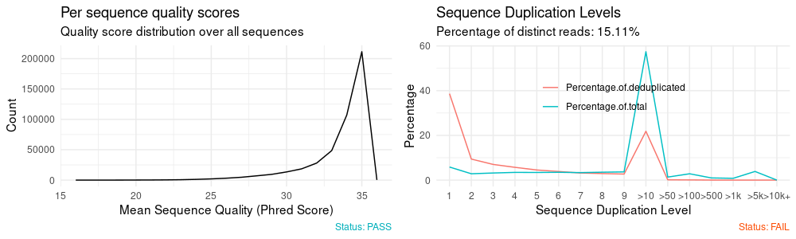

[1] “QC results for sample 908150_H_dinops_Guadalcanal_fastqc.zip”

| Measure | Value |
| --- | --- |
| Filename | 908150_H_dinops_Guadalcanal.fq.gz |
| File type | Conventional base calls |
| Encoding | Sanger / Illumina 1.9 |
| Total Sequences | 123287 |
| Sequences flagged as poor quality | 0 |
| Sequence length | 145 |
| %GC | 38 |

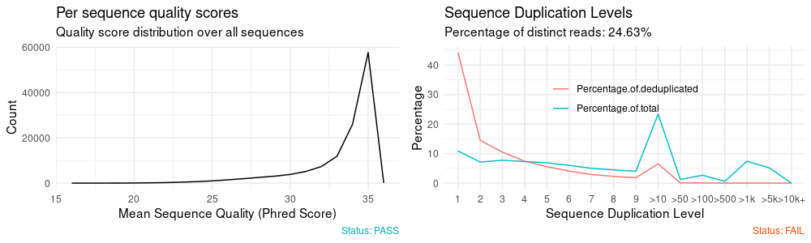

[1] “QC results for sample 908151_H_diadema_Guadalcanal_fastqc.zip”

| Measure | Value |
| --- | --- |
| Filename | 908151_H_diadema_Guadalcanal.fq.gz |
| File type | Conventional base calls |
| Encoding | Sanger / Illumina 1.9 |
| Total Sequences | 3189301 |
| Sequences flagged as poor quality | 0 |
| Sequence length | 145 |
| %GC | 38 |

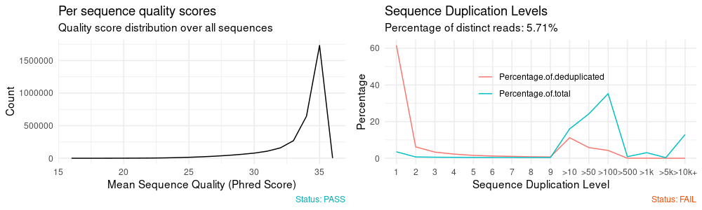

[1] “QC results for sample 908152_H_diadema_Guadalcanal_fastqc.zip”

| Measure | Value |
| --- | --- |
| Filename | 908152_H_diadema_Guadalcanal.fq.gz |
| File type | Conventional base calls |
| Encoding | Sanger / Illumina 1.9 |
| Total Sequences | 1388568 |
| Sequences flagged as poor quality | 0 |
| Sequence length | 145 |
| %GC | 37 |

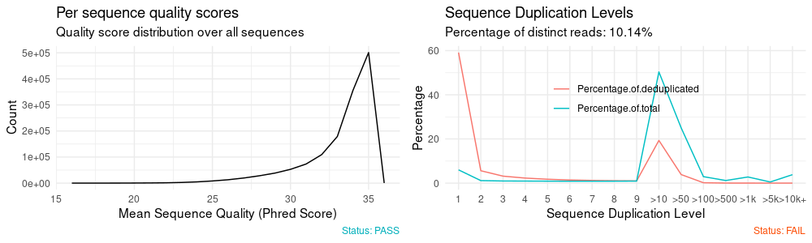

[1] “QC results for sample 908153a_H_dinops_Guadalcanal_fastqc.zip”

| Measure | Value |
| --- | --- |
| Filename | 908153a_H_dinops_Guadalcanal.fq.gz |
| File type | Conventional base calls |
| Encoding | Sanger / Illumina 1.9 |
| Total Sequences | 7332578 |
| Sequences flagged as poor quality | 0 |
| Sequence length | 145 |
| %GC | 37 |

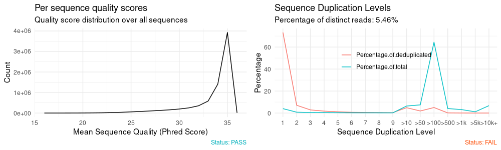

[1] “QC results for sample 908154_H_dinops_Guadalcanal_fastqc.zip”

| Measure | Value |
| --- | --- |
| Filename | 908154_H_dinops_Guadalcanal.fq.gz |
| File type | Conventional base calls |
| Encoding | Sanger / Illumina 1.9 |
| Total Sequences | 521388 |
| Sequences flagged as poor quality | 0 |
| Sequence length | 145 |
| %GC | 37 |

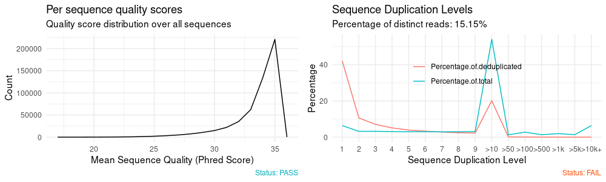

[1] “QC results for sample 908155_H_dinops_Guadalcanal_fastqc.zip”

| Measure | Value |
| --- | --- |
| Filename | 908155_H_dinops_Guadalcanal.fq.gz |
| File type | Conventional base calls |
| Encoding | Sanger / Illumina 1.9 |
| Total Sequences | 989397 |
| Sequences flagged as poor quality | 0 |
| Sequence length | 145 |
| %GC | 37 |

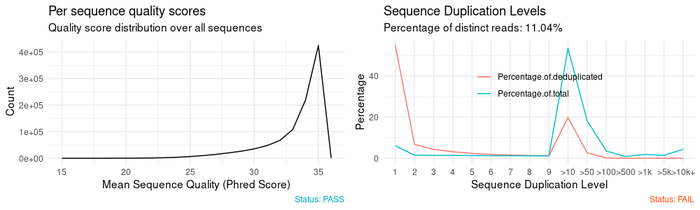

[1] “QC results for sample 908156_H_diadema_Guadalcanal_fastqc.zip”

| Measure | Value |
| --- | --- |
| Filename | 908156_H_diadema_Guadalcanal.fq.gz |
| File type | Conventional base calls |
| Encoding | Sanger / Illumina 1.9 |
| Total Sequences | 4283313 |
| Sequences flagged as poor quality | 0 |
| Sequence length | 145 |
| %GC | 37 |

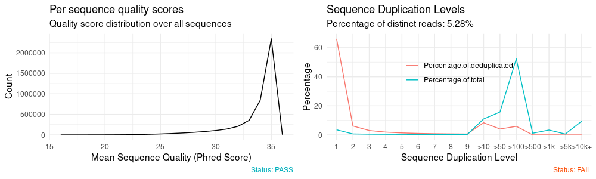

[1] “QC results for sample 908208_H_diadema_Guadalcanal_fastqc.zip”

| Measure | Value |
| --- | --- |
| Filename | 908208_H_diadema_Guadalcanal.fq.gz |
| File type | Conventional base calls |
| Encoding | Sanger / Illumina 1.9 |
| Total Sequences | 769417 |
| Sequences flagged as poor quality | 0 |
| Sequence length | 145 |
| %GC | 37 |

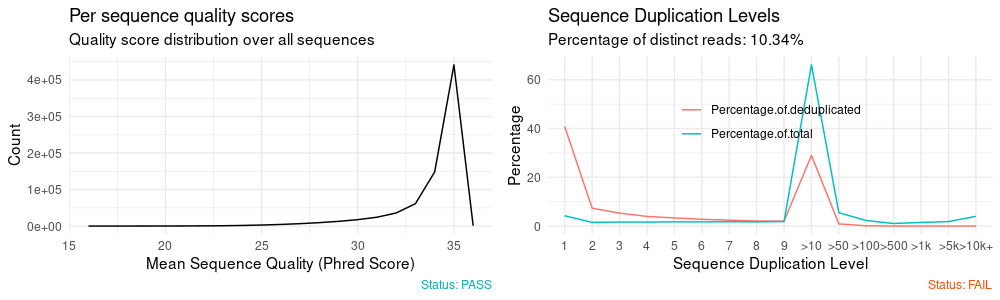

[1] “QC results for sample JM19686_H_diadema_Choiseul_fastqc.zip”

| Measure | Value |
| --- | --- |
| Filename | JM19686_H_diadema_Choiseul.fq.gz |
| File type | Conventional base calls |
| Encoding | Sanger / Illumina 1.9 |
| Total Sequences | 5088 |
| Sequences flagged as poor quality | 0 |
| Sequence length | 145 |
| %GC | 35 |

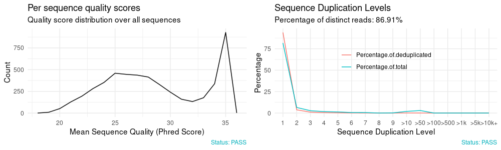

[1] “QC results for sample KO-P3_S3_R1_001_fastqc.zip”

| Measure | Value |
| --- | --- |
| Filename | KO-P3_S3_R1_001.fastq.gz |
| File type | Conventional base calls |
| Encoding | Sanger / Illumina 1.9 |
| Total Sequences | 122147979 |
| Sequences flagged as poor quality | 0 |
| Sequence length | 151 |
| %GC | 37 |

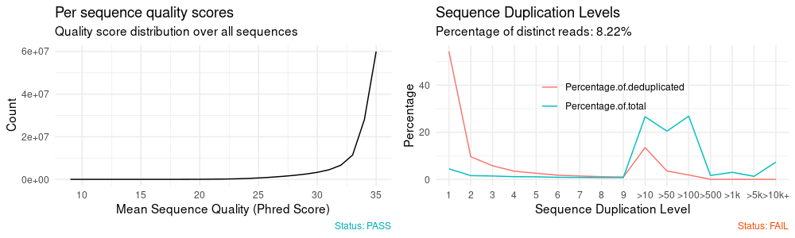

[1] “QC results for sample KVO150_H_diadema_Isabel_fastqc.zip”

| Measure | Value |
| --- | --- |
| Filename | KVO150_H_diadema_Isabel.fq.gz |
| File type | Conventional base calls |
| Encoding | Sanger / Illumina 1.9 |
| Total Sequences | 34578 |
| Sequences flagged as poor quality | 0 |
| Sequence length | 145 |
| %GC | 36 |

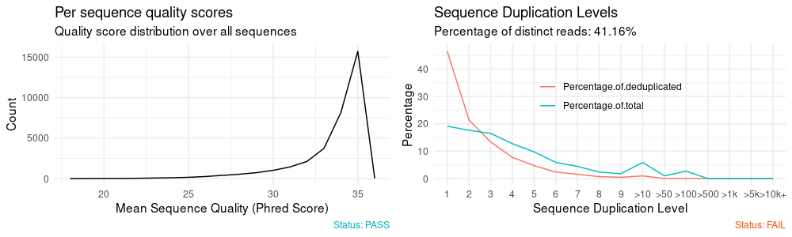

[1] “QC results for sample KVO168_H_diadema_Isabel_fastqc.zip”

| Measure | Value |
| --- | --- |
| Filename | KVO168_H_diadema_Isabel.fq.gz |
| File type | Conventional base calls |
| Encoding | Sanger / Illumina 1.9 |
| Total Sequences | 266025 |
| Sequences flagged as poor quality | 0 |
| Sequence length | 145 |
| %GC | 36 |

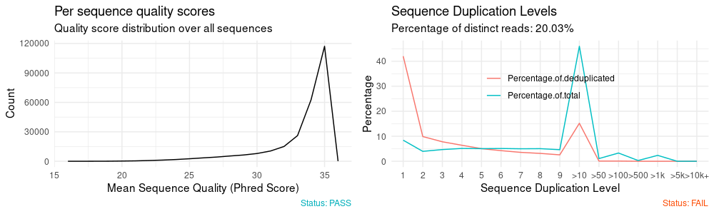

[1] “QC results for sample KVO169_H_diadema_Isabel_fastqc.zip”

| Measure | Value |
| --- | --- |
| Filename | KVO169_H_diadema_Isabel.fq.gz |
| File type | Conventional base calls |
| Encoding | Sanger / Illumina 1.9 |
| Total Sequences | 499713 |
| Sequences flagged as poor quality | 0 |
| Sequence length | 145 |
| %GC | 36 |

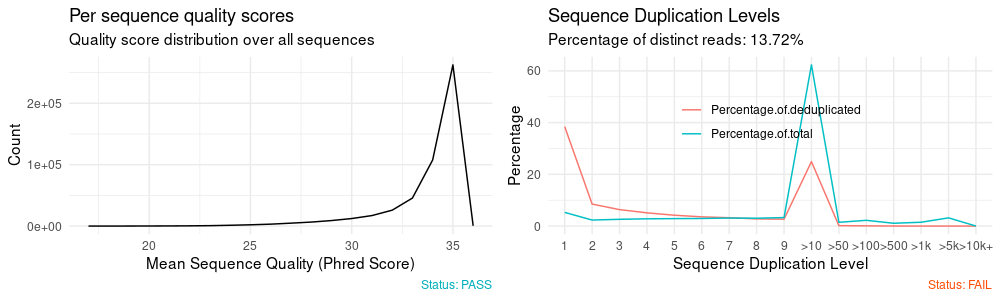

[1] “QC results for sample KVO170_H_diadema_Isabel_fastqc.zip”

| Measure | Value |
| --- | --- |
| Filename | KVO170_H_diadema_Isabel.fq.gz |
| File type | Conventional base calls |
| Encoding | Sanger / Illumina 1.9 |
| Total Sequences | 825167 |
| Sequences flagged as poor quality | 0 |
| Sequence length | 145 |
| %GC | 36 |

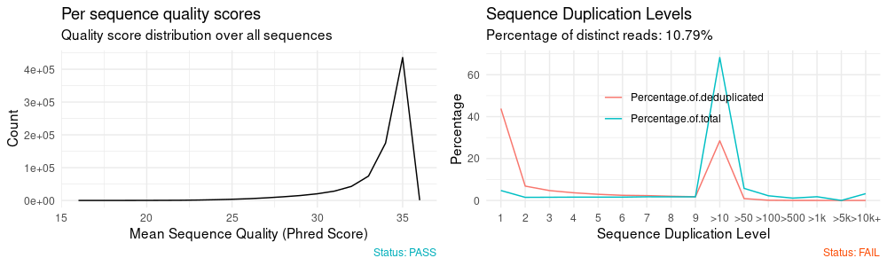

[1] “QC results for sample KVO171_H_diadema_Isabel_fastqc.zip”

| Measure | Value |
| --- | --- |
| Filename | KVO171_H_diadema_Isabel.fq.gz |
| File type | Conventional base calls |
| Encoding | Sanger / Illumina 1.9 |
| Total Sequences | 271596 |
| Sequences flagged as poor quality | 0 |
| Sequence length | 145 |
| %GC | 36 |

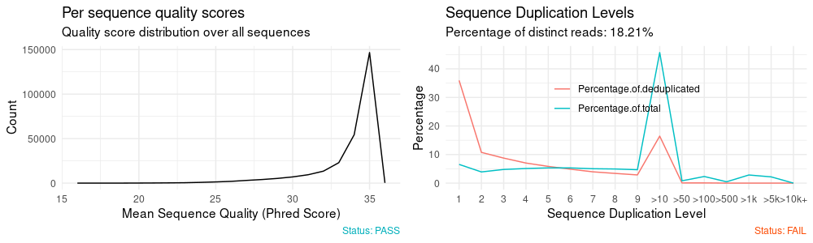

[1] “QC results for sample KVO172_H_diadema_Isabel_fastqc.zip”

| Measure | Value |
| --- | --- |
| Filename | KVO172_H_diadema_Isabel.fq.gz |
| File type | Conventional base calls |
| Encoding | Sanger / Illumina 1.9 |
| Total Sequences | 98438 |
| Sequences flagged as poor quality | 0 |
| Sequence length | 145 |
| %GC | 36 |

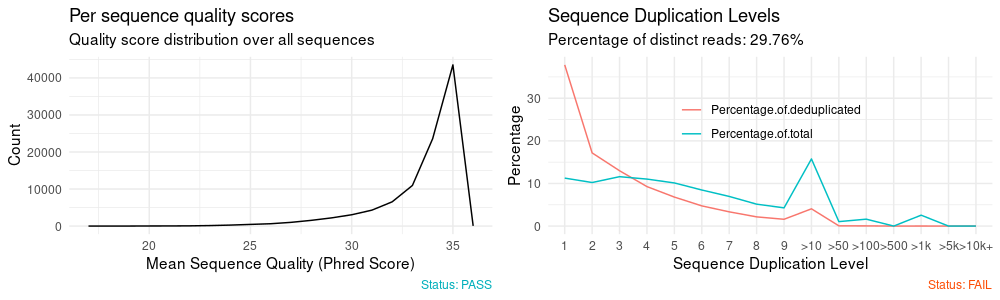

[1] “QC results for sample KVO242_H_dinops_Rendova_fastqc.zip”

| Measure | Value |
| --- | --- |
| Filename | KVO242_H_dinops_Rendova.fq.gz |
| File type | Conventional base calls |
| Encoding | Sanger / Illumina 1.9 |
| Total Sequences | 1355358 |
| Sequences flagged as poor quality | 0 |
| Sequence length | 145 |
| %GC | 37 |

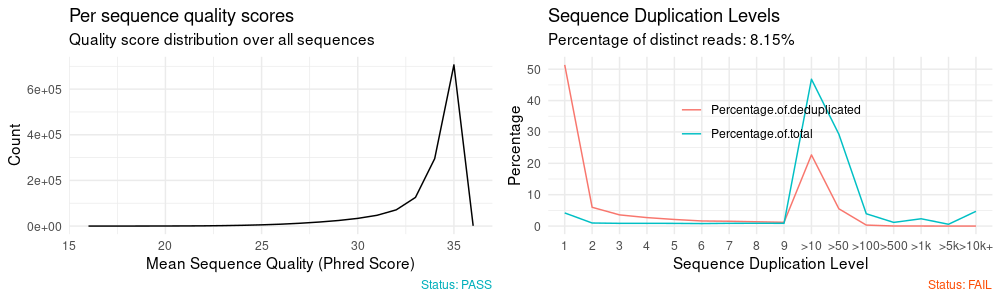

[1] “QC results for sample KVO243_H_dinops_Rendova_fastqc.zip”

| Measure | Value |
| --- | --- |
| Filename | KVO243_H_dinops_Rendova.fq.gz |
| File type | Conventional base calls |
| Encoding | Sanger / Illumina 1.9 |
| Total Sequences | 1797464 |
| Sequences flagged as poor quality | 0 |
| Sequence length | 145 |
| %GC | 37 |

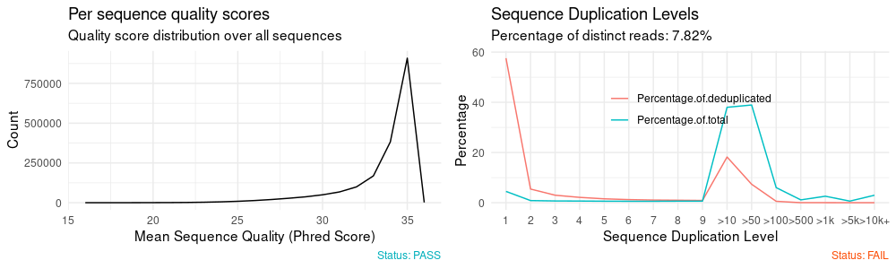

[1] “QC results for sample KVO245_H_dinops_Rendova_fastqc.zip”

| Measure | Value |
| --- | --- |
| Filename | KVO245_H_dinops_Rendova.fq.gz |
| File type | Conventional base calls |
| Encoding | Sanger / Illumina 1.9 |
| Total Sequences | 4204013 |
| Sequences flagged as poor quality | 0 |
| Sequence length | 145 |
| %GC | 36 |

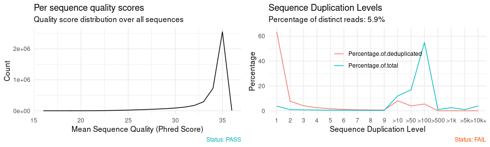

[1] “QC results for sample KVO246_H_dinops_Rendova_fastqc.zip”

| Measure | Value |
| --- | --- |
| Filename | KVO246_H_dinops_Rendova.fq.gz |
| File type | Conventional base calls |
| Encoding | Sanger / Illumina 1.9 |
| Total Sequences | 2153670 |
| Sequences flagged as poor quality | 0 |
| Sequence length | 145 |
| %GC | 36 |

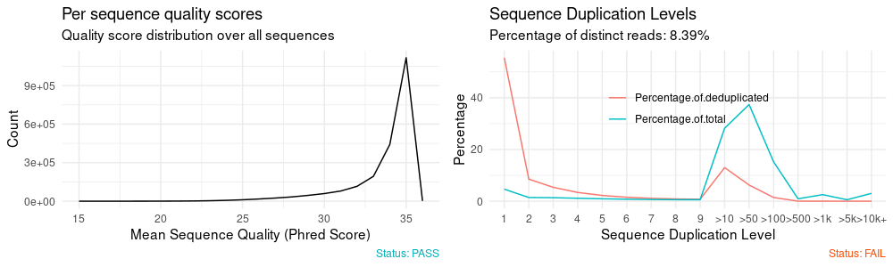

[1] “QC results for sample KVO248_H_diadema_Rendova_fastqc.zip”

| Measure | Value |
| --- | --- |
| Filename | KVO248_H_diadema_Rendova.fq.gz |
| File type | Conventional base calls |
| Encoding | Sanger / Illumina 1.9 |
| Total Sequences | 1799491 |
| Sequences flagged as poor quality | 0 |
| Sequence length | 145 |
| %GC | 36 |

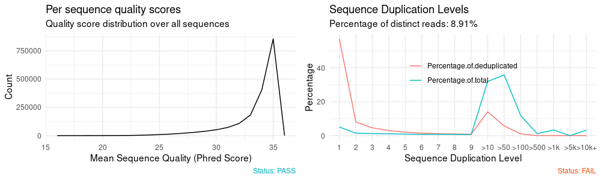

[1] “QC results for sample THL1048_H_dinops_Guadalcanal_fastqc.zip”

| Measure | Value |
| --- | --- |
| Filename | THL1048_H_dinops_Guadalcanal.fq.gz |
| File type | Conventional base calls |
| Encoding | Sanger / Illumina 1.9 |
| Total Sequences | 4848 |
| Sequences flagged as poor quality | 0 |
| Sequence length | 145 |
| %GC | 35 |

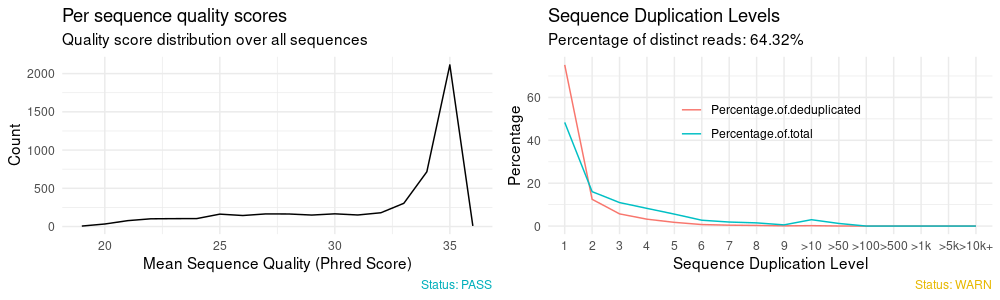

[1] “QC results for sample THL1120_H_dinops_Gatokae_fastqc.zip”

| Measure | Value |
| --- | --- |
| Filename | THL1120_H_dinops_Gatokae.fq.gz |
| File type | Conventional base calls |
| Encoding | Sanger / Illumina 1.9 |
| Total Sequences | 3212 |
| Sequences flagged as poor quality | 0 |
| Sequence length | 145 |
| %GC | 36 |

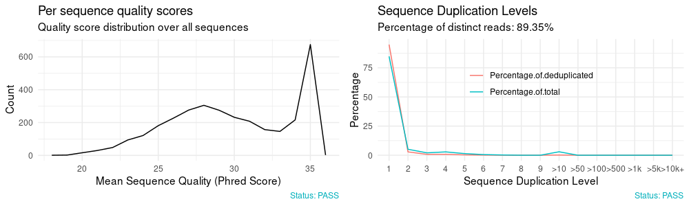

[1] “QC results for sample THL1121_H_dinops_Gatokae_fastqc.zip”

| Measure | Value |
| --- | --- |
| Filename | THL1121_H_dinops_Gatokae.fq.gz |
| File type | Conventional base calls |
| Encoding | Sanger / Illumina 1.9 |
| Total Sequences | 6874 |
| Sequences flagged as poor quality | 0 |
| Sequence length | 145 |
| %GC | 35 |

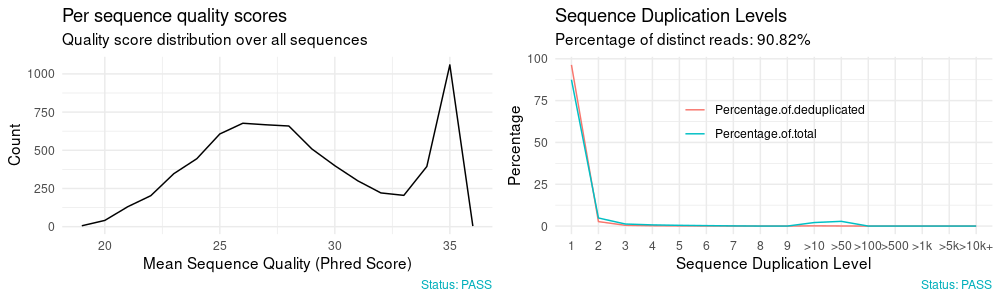

[1] “QC results for sample THL1122_H_dinops_Gatokae_fastqc.zip”

| Measure | Value |
| --- | --- |
| Filename | THL1122_H_dinops_Gatokae.fq.gz |
| File type | Conventional base calls |
| Encoding | Sanger / Illumina 1.9 |
| Total Sequences | 288 |
| Sequences flagged as poor quality | 0 |
| Sequence length | 145 |
| %GC | 36 |

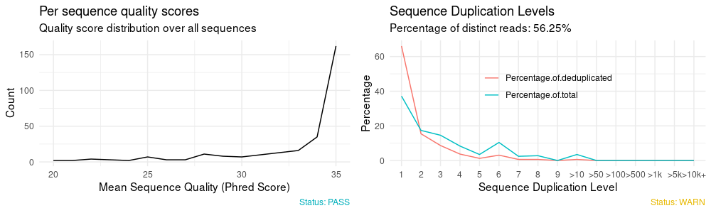

[1] “QC results for sample THL1154_H_demissus_Makira_fastqc.zip”

| Measure | Value |
| --- | --- |
| Filename | THL1154_H_demissus_Makira.fq.gz |
| File type | Conventional base calls |
| Encoding | Sanger / Illumina 1.9 |
| Total Sequences | 6361 |
| Sequences flagged as poor quality | 0 |
| Sequence length | 145 |
| %GC | 36 |

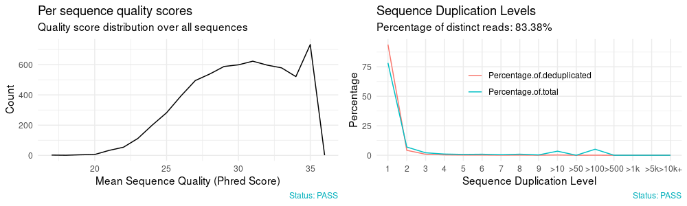

[1] “QC results for sample THL1156_H_demissus_Makira_fastqc.zip”

| Measure | Value |
| --- | --- |
| Filename | THL1156_H_demissus_Makira.fq.gz |
| File type | Conventional base calls |
| Encoding | Sanger / Illumina 1.9 |
| Total Sequences | 819353 |
| Sequences flagged as poor quality | 0 |
| Sequence length | 145 |
| %GC | 36 |

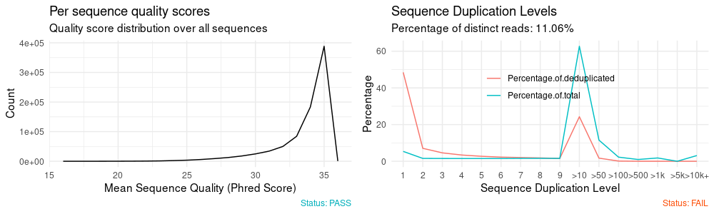

[1] “QC results for sample THL1167_H_diadema_Guadalcanal_fastqc.zip”

| Measure | Value |
| --- | --- |
| Filename | THL1167_H_diadema_Guadalcanal.fq.gz |
| File type | Conventional base calls |
| Encoding | Sanger / Illumina 1.9 |
| Total Sequences | 1409 |
| Sequences flagged as poor quality | 0 |
| Sequence length | 145 |
| %GC | 37 |

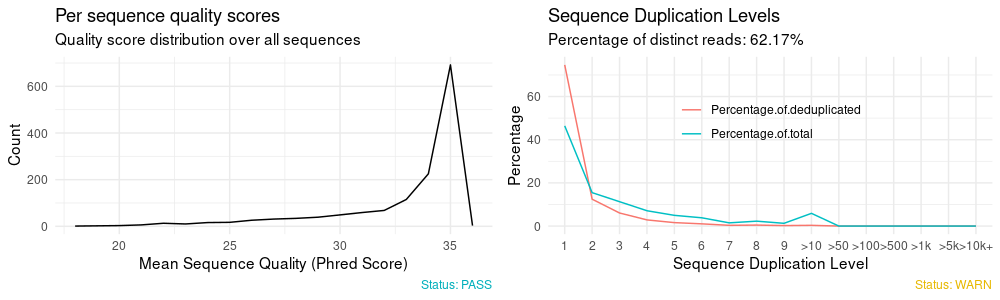

[1] “QC results for sample THL1172_H_dinops_Guadalcanal_fastqc.zip”

| Measure | Value |
| --- | --- |
| Filename | THL1172_H_dinops_Guadalcanal.fq.gz |
| File type | Conventional base calls |
| Encoding | Sanger / Illumina 1.9 |
| Total Sequences | 173703 |
| Sequences flagged as poor quality | 0 |
| Sequence length | 145 |
| %GC | 38 |

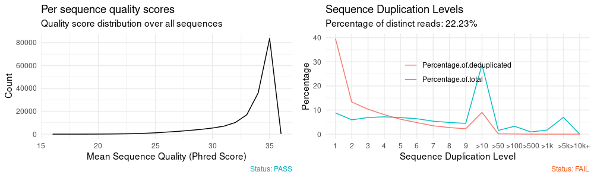

[1] “QC results for sample THL1173_H_dinops_Guadalcanal_fastqc.zip”

| Measure | Value |
| --- | --- |
| Filename | THL1173_H_dinops_Guadalcanal.fq.gz |
| File type | Conventional base calls |
| Encoding | Sanger / Illumina 1.9 |
| Total Sequences | 979903 |
| Sequences flagged as poor quality | 0 |
| Sequence length | 145 |
| %GC | 37 |

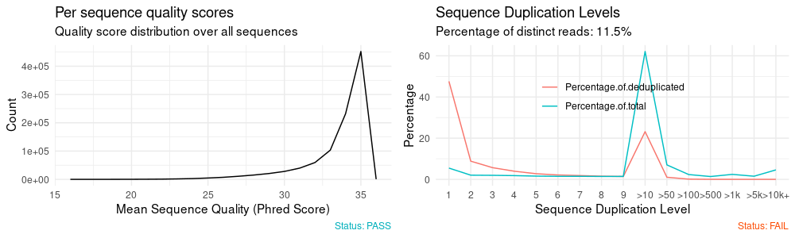

[1] “QC results for sample THL1221_H_diadema_Gatokae_fastqc.zip”

| Measure | Value |
| --- | --- |
| Filename | THL1221_H_diadema_Gatokae.fq.gz |
| File type | Conventional base calls |
| Encoding | Sanger / Illumina 1.9 |
| Total Sequences | 2435 |
| Sequences flagged as poor quality | 0 |
| Sequence length | 145 |
| %GC | 37 |

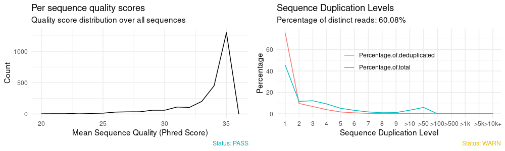

[1] “QC results for sample THL1223_H_dinops_Guadalcanal_fastqc.zip”

| Measure | Value |
| --- | --- |
| Filename | THL1223_H_dinops_Guadalcanal.fq.gz |
| File type | Conventional base calls |
| Encoding | Sanger / Illumina 1.9 |
| Total Sequences | 6655 |
| Sequences flagged as poor quality | 0 |
| Sequence length | 145 |
| %GC | 36 |

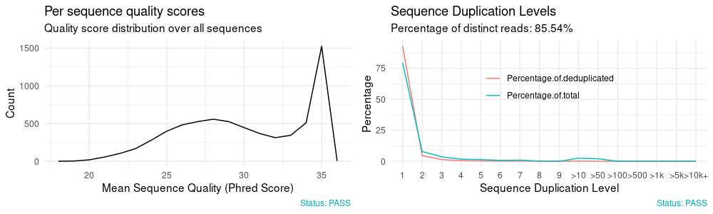

[1] “QC results for sample THL17193_H_diadema_Ngella_fastqc.zip”

| Measure | Value |
| --- | --- |
| Filename | THL17193_H_diadema_Ngella.fq.gz |
| File type | Conventional base calls |
| Encoding | Sanger / Illumina 1.9 |
| Total Sequences | 3046762 |
| Sequences flagged as poor quality | 0 |
| Sequence length | 145 |
| %GC | 38 |

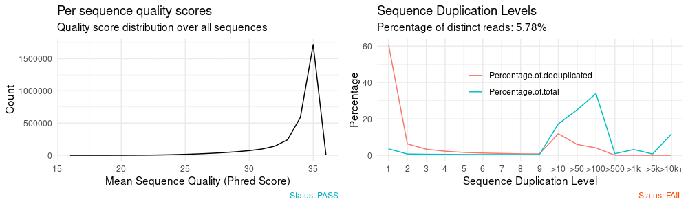

[1] “QC results for sample THL17194_H_diadema_Ngella_fastqc.zip”

| Measure | Value |
| --- | --- |
| Filename | THL17194_H_diadema_Ngella.fq.gz |
| File type | Conventional base calls |
| Encoding | Sanger / Illumina 1.9 |
| Total Sequences | 1218936 |
| Sequences flagged as poor quality | 0 |
| Sequence length | 145 |
| %GC | 37 |

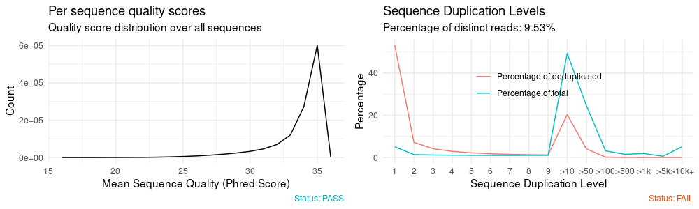

[1] “QC results for sample THL17195_H_diadema_Ngella_fastqc.zip”

| Measure | Value |
| --- | --- |
| Filename | THL17195_H_diadema_Ngella.fq.gz |
| File type | Conventional base calls |
| Encoding | Sanger / Illumina 1.9 |
| Total Sequences | 1825457 |
| Sequences flagged as poor quality | 0 |
| Sequence length | 145 |
| %GC | 37 |

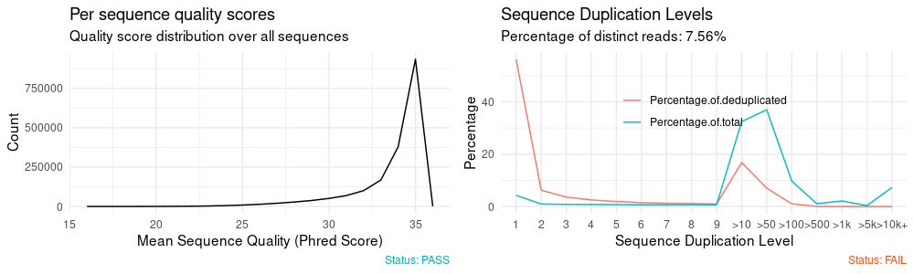

[1] “QC results for sample THL17197_H_diadema_Ngella_fastqc.zip”

| Measure | Value |
| --- | --- |
| Filename | THL17197_H_diadema_Ngella.fq.gz |
| File type | Conventional base calls |
| Encoding | Sanger / Illumina 1.9 |
| Total Sequences | 1551531 |
| Sequences flagged as poor quality | 0 |
| Sequence length | 145 |
| %GC | 37 |

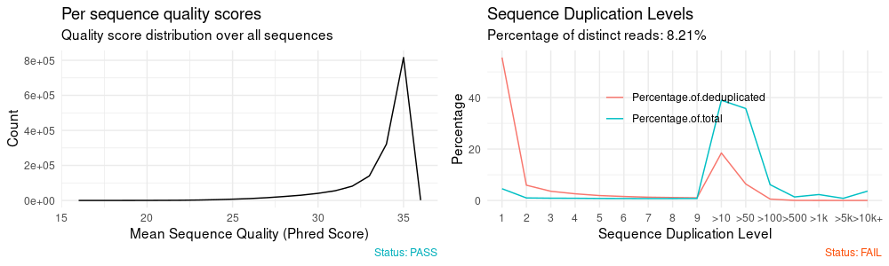

[1] “QC results for sample THL17198_H_diadema_Ngella_fastqc.zip”

| Measure | Value |
| --- | --- |
| Filename | THL17198_H_diadema_Ngella.fq.gz |
| File type | Conventional base calls |
| Encoding | Sanger / Illumina 1.9 |
| Total Sequences | 6622220 |
| Sequences flagged as poor quality | 0 |
| Sequence length | 145 |
| %GC | 37 |

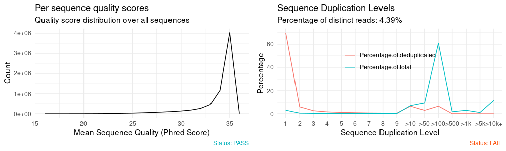

[1] “QC results for sample THL17199_H_diadema_Ngella_fastqc.zip”

| Measure | Value |
| --- | --- |
| Filename | THL17199_H_diadema_Ngella.fq.gz |
| File type | Conventional base calls |
| Encoding | Sanger / Illumina 1.9 |
| Total Sequences | 1508601 |
| Sequences flagged as poor quality | 0 |
| Sequence length | 145 |
| %GC | 37 |

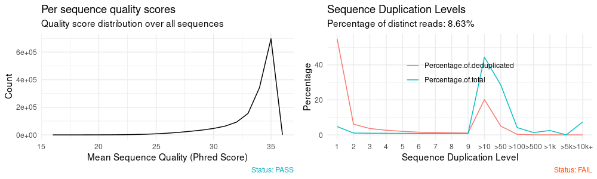

[1] “QC results for sample WD1705_H_diadema_E_New_Britain_fastqc.zip”

| Measure | Value |
| --- | --- |
| Filename | WD1705_H_diadema_E_New_Britain.fq.gz |
| File type | Conventional base calls |
| Encoding | Sanger / Illumina 1.9 |
| Total Sequences | 1336956 |
| Sequences flagged as poor quality | 0 |
| Sequence length | 145 |
| %GC | 37 |

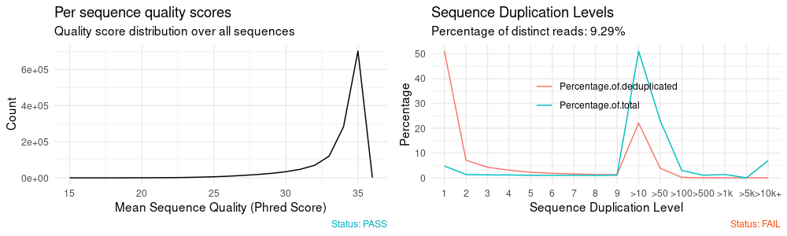

[1] “QC results for sample WD2047_H_diadema_Simbu_Prov_fastqc.zip”

| Measure | Value |
| --- | --- |
| Filename | WD2047_H_diadema_Simbu_Prov.fq.gz |
| File type | Conventional base calls |
| Encoding | Sanger / Illumina 1.9 |
| Total Sequences | 704726 |
| Sequences flagged as poor quality | 0 |
| Sequence length | 145 |
| %GC | 36 |

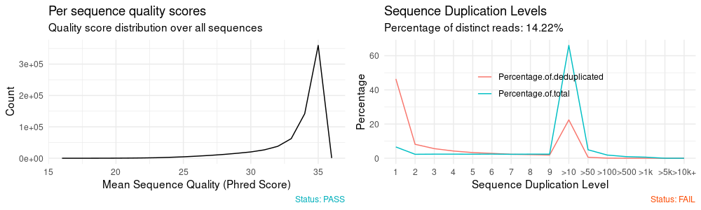

[1] “QC results for sample WD2074_H_diadema_Gulf_Prov_fastqc.zip”

| Measure | Value |
| --- | --- |
| Filename | WD2074_H_diadema_Gulf_Prov.fq.gz |
| File type | Conventional base calls |
| Encoding | Sanger / Illumina 1.9 |
| Total Sequences | 951142 |
| Sequences flagged as poor quality | 0 |
| Sequence length | 145 |
| %GC | 36 |

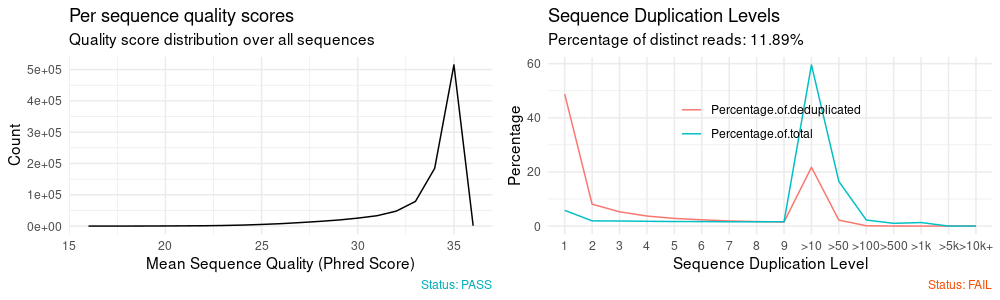

```r
#aggregate the reports by pointing this function to the folder holding output of fastqc()
qc <- qc_aggregate(qc.dir, progressbar = F)

#stats per sample
knitr::kable(qc_stats(qc))
```

| sample | pct.dup | pct.gc | tot.seq | seq.length |
| --- | --- | --- | --- | --- |
| 908108_H_diadema_Gatokae.fq.gz | 84.89 | 36 | 456195 | 145 |
| 908150_H_dinops_Guadalcanal.fq.gz | 75.37 | 38 | 123287 | 145 |
| 908151_H_diadema_Guadalcanal.fq.gz | 94.29 | 38 | 3189301 | 145 |
| 908152_H_diadema_Guadalcanal.fq.gz | 89.86 | 37 | 1388568 | 145 |
| 908153a_H_dinops_Guadalcanal.fq.gz | 94.54 | 37 | 7332578 | 145 |
| 908154_H_dinops_Guadalcanal.fq.gz | 84.85 | 37 | 521388 | 145 |
| 908155_H_dinops_Guadalcanal.fq.gz | 88.96 | 37 | 989397 | 145 |
| 908156_H_diadema_Guadalcanal.fq.gz | 94.72 | 37 | 4283313 | 145 |
| 908208_H_diadema_Guadalcanal.fq.gz | 89.66 | 37 | 769417 | 145 |
| JM19686_H_diadema_Choiseul.fq.gz | 13.09 | 35 | 5088 | 145 |
| KO-P3_S3_R1_001 | 91.78 | 37 | 122147979 | 151 |
| KVO150_H_diadema_Isabel.fq.gz | 58.84 | 36 | 34578 | 145 |
| KVO168_H_diadema_Isabel.fq.gz | 79.97 | 36 | 266025 | 145 |
| KVO169_H_diadema_Isabel.fq.gz | 86.28 | 36 | 499713 | 145 |
| KVO170_H_diadema_Isabel.fq.gz | 89.21 | 36 | 825167 | 145 |
| KVO171_H_diadema_Isabel.fq.gz | 81.79 | 36 | 271596 | 145 |
| KVO172_H_diadema_Isabel.fq.gz | 70.24 | 36 | 98438 | 145 |
| KVO242_H_dinops_Rendova.fq.gz | 91.85 | 37 | 1355358 | 145 |
| KVO243_H_dinops_Rendova.fq.gz | 92.18 | 37 | 1797464 | 145 |
| KVO245_H_dinops_Rendova.fq.gz | 94.10 | 36 | 4204013 | 145 |
| KVO246_H_dinops_Rendova.fq.gz | 91.61 | 36 | 2153670 | 145 |
| KVO248_H_diadema_Rendova.fq.gz | 91.09 | 36 | 1799491 | 145 |
| THL1048_H_dinops_Guadalcanal.fq.gz | 35.68 | 35 | 4848 | 145 |
| THL1120_H_dinops_Gatokae.fq.gz | 10.65 | 36 | 3212 | 145 |
| THL1121_H_dinops_Gatokae.fq.gz | 9.18 | 35 | 6874 | 145 |
| THL1122_H_dinops_Gatokae.fq.gz | 43.75 | 36 | 288 | 145 |
| THL1154_H_demissus_Makira.fq.gz | 16.62 | 36 | 6361 | 145 |
| THL1156_H_demissus_Makira.fq.gz | 88.94 | 36 | 819353 | 145 |
| THL1167_H_diadema_Guadalcanal.fq.gz | 37.83 | 37 | 1409 | 145 |
| THL1172_H_dinops_Guadalcanal.fq.gz | 77.77 | 38 | 173703 | 145 |
| THL1173_H_dinops_Guadalcanal.fq.gz | 88.50 | 37 | 979903 | 145 |
| THL1221_H_diadema_Gatokae.fq.gz | 39.92 | 37 | 2435 | 145 |
| THL1223_H_dinops_Guadalcanal.fq.gz | 14.46 | 36 | 6655 | 145 |
| THL17193_H_diadema_Ngella.fq.gz | 94.22 | 38 | 3046762 | 145 |
| THL17194_H_diadema_Ngella.fq.gz | 90.47 | 37 | 1218936 | 145 |
| THL17195_H_diadema_Ngella.fq.gz | 92.44 | 37 | 1825457 | 145 |
| THL17197_H_diadema_Ngella.fq.gz | 91.79 | 37 | 1551531 | 145 |
| THL17198_H_diadema_Ngella.fq.gz | 95.61 | 37 | 6622220 | 145 |
| THL17199_H_diadema_Ngella.fq.gz | 91.37 | 37 | 1508601 | 145 |
| WD1705_H_diadema_E_New_Britain.fq.gz | 90.71 | 37 | 1336956 | 145 |
| WD2047_H_diadema_Simbu_Prov.fq.gz | 85.78 | 36 | 704726 | 145 |
| WD2074_H_diadema_Gulf_Prov.fq.gz | 88.11 | 36 | 951142 | 145 |

### solid red line = median sample value

### dashed red line = 10% of median sample value

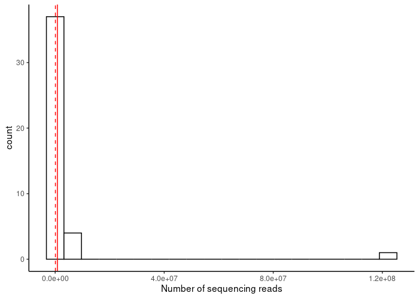

```r
#save stats info as an object
stats.info<-qc_stats(qc)
#make tot.seq numeric
stats.info$tot.seq<-as.numeric(stats.info$tot.seq)

#make histogram of number of sequence reads for each sample
ggplot(stats.info, aes(x=tot.seq))+
              geom_histogram(color="black", fill="white", bins=20)+
              geom_vline(aes(xintercept=median(tot.seq)), color = "red")+
              geom_vline(aes(xintercept=median(tot.seq)*.1), color = "red", lty=14)+
              theme_classic()+
              xlab("Number of sequencing reads")
```

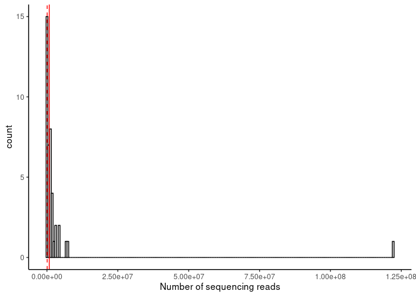

```r
#solid red line = median sample value
#dashed red line = 10% of median sample value
ggplot(stats.info, aes(x=tot.seq))+
              geom_histogram(color="black", fill="white", bins=200)+
              geom_vline(aes(xintercept=median(tot.seq)), color = "red")+
              geom_vline(aes(xintercept=median(tot.seq)*.1), color = "red", lty=14)+
              theme_classic()+
              xlab("Number of sequencing reads")
```

```r
#show me the samples that have less than 10% of the number of reads as the median sample from this experiment (these should be dropped immediately)
print(paste("Median sample contains", median(stats.info$tot.seq), "reads. The following samples contain less than", median(stats.info$tot.seq)*.1, "reads (10% of the median), and should likely be dropped"))
```

[1] “Median sample contains 822260 reads. The following samples contain less than 82226 reads (10% of the median), and should likely be dropped”

```r
knitr::kable(stats.info[stats.info$tot.seq < median(stats.info$tot.seq)*.1,])
```

| sample | pct.dup | pct.gc | tot.seq | seq.length |
| --- | --- | --- | --- | --- |
| JM19686_H_diadema_Choiseul.fq.gz | 13.09 | 35 | 5088 | 145 |
| KVO150_H_diadema_Isabel.fq.gz | 58.84 | 36 | 34578 | 145 |
| THL1048_H_dinops_Guadalcanal.fq.gz | 35.68 | 35 | 4848 | 145 |
| THL1120_H_dinops_Gatokae.fq.gz | 10.65 | 36 | 3212 | 145 |
| THL1121_H_dinops_Gatokae.fq.gz | 9.18 | 35 | 6874 | 145 |
| THL1122_H_dinops_Gatokae.fq.gz | 43.75 | 36 | 288 | 145 |
| THL1154_H_demissus_Makira.fq.gz | 16.62 | 36 | 6361 | 145 |
| THL1167_H_diadema_Guadalcanal.fq.gz | 37.83 | 37 | 1409 | 145 |
| THL1221_H_diadema_Gatokae.fq.gz | 39.92 | 37 | 2435 | 145 |
| THL1223_H_dinops_Guadalcanal.fq.gz | 14.46 | 36 | 6655 | 145 |